# c6w1 lecture notes

Robert Handsfield

02/08/2015

# 0101 Introduction to Statistical Inference

Statistical inference is the process of **generating conclusions** about a population from a noisy sample. Statistical inference allows us to step outside our data, and relate the sample to the real world by drawing conclusions and making predictions.

In terms of Bayesian vs Frequency statistics, this course will use frequency statistics for inferences exclusively.

The formal process of statistical inference is using data from a sample to estimate population traits. A sample median will estimate the population median, a sample variance will estimate a population variance, etc. The estimation is done by connecting the sample to a population through a *probability model* (which requires assumptions). In all cases, the sample trait is called the **estimator**, and the population trait is called the **estimand**.

# 0201 Introduction to Probability

For more detailed info, refer to Brian Caffo’s [Biostatistics Bootcamp Lectures](https://www.youtube.com/watch?v=jkUqDVtpKs4&list=PLpl-gQkQivXhk6qSyiNj51qamjAtZISJ-) on youtube.

- Given a random experiment, like rolling a die, any probability measure is a population quantity that summarizes the randomness.
- The probabilities are **not** functions of rolling the die, they are intrinsic properties of the die themselves.

## Probability Calculus

The Probability Calculus is the set of rules that probability must always follow.

All the rules are restatements or consequences of

Probability:

1. operates on the potential *outcomes* from an experiment
2. assigns the outcome a number between 0 and 1
3. Such that there is a probability of 1 that *something* occurs (when a die is rolled),
4. And the probability of any 2 sets of independent outcomes is the **sum** of their respective probabilities
   - Probability of A **or** B, *exclusive probability spaces*:
   - $P(A \cup B) = P (A) + P (B)$

### The Rules

#### The probability that:

1. Nothing happens is 0
2. Anything happens is 1
3. Something happens is 1 minus the probability of the opposite thing happening (something not happening)
   - $P(A) = 1 - P(\not{A})$
4. At least 1 of many mutually exclusive things happens, is the sum of all their respective probabilities
   - $P(A \cup B) = P (A) + P (B)$

#### If:

5. B must happen in order for A to happen, then A’s probability is less than B
   - $P(A) < P(B)$

#### For any two outcomes:

6. The probability that at least 1 happens is the sum of their probabilities minus their intersection
   - **In English:** You can’t add probabilities if they have something in common
   - In math: Their union is their sum, minus their intersection
   - Probability of A **or** B, *exclusive probability spaces*:
   - $P(A \cup B) = P (A) + P (B) - P(A \cap B) ~=~ P(A) + P(B) - P(A) \times P(B)$

### Example:

The National Sleep Foundation ([www.sleepfoundation.org](http://www.sleepfoundation.org/)) reports that around 3% of the American population has sleep apnea. They also report that around 10% of the North American and European population has restless leg syndrome. Does this imply that 13% of people will have at least one sleep problems of these sorts?

**No**, we can’t just add the probabilities because some people may have both.  
The outcomes are **not mutually exclusive**.

To find the percentage of people with at least 1 sleep disorder, must add their probabilities, then subtract **1** of their intersections:

$$P(Apnea \cup RLS) = P (Apnea) + P (RLS) - P(Apnea \cap RLS)$$
$$P(Apnea \cup RLS) = P (Apnea) + P (RLS) - P(Apnea) \times P(RLS)$$

## 0202 Probability Mass Functions

Probability calculus is fine for understanding results from a single experiment. To understand results from millions of repetitions of that experiement, we need probability densities, and mass functions.

Densities and Mass Functions are also *population quantities*, intrinsic properties of the populations themselves. They tell nothing about what occurs in the data. In fact, we use the data to *estimate* properties of the population.

- A **random variable** is a *numerical outcome* of an event
  - they can be discrete or continuous

Examples of Discrete Variables:

- the binary outcome of a coin flip
- the outcome of a die roll
- website traffic on a given day (often modeled w/ Poisson distributions)
- the hypertension *status* of a person randomly drawn from a population
- the number of people clicking a banner ad

Examples of Continuous Random Variables: * the BMI of a subject 4 years after baseline measurement * the score from an IQ test

### The Probability Mass Function

The probability mass function evaluated at a value yields the probability that a random variable takes that value. Probability mass functions *generate* probability densities.

*(FYI: the binomial pmf canonically models coin flips, and the Poisson pmf canonically models counts.)*

#### Example – A die roll:

The pmf for a die roll assigns probability $1 \over 6$ to each outcome.

#### Example – A coin flip:

A binomial pmf creates the well-known *Bernoulli distribution* .

*An upper-case letter $\left( X \right)$ denotes a known output of the pmf.* In the case of a coin flip, it’s $0$ or $1$.

$$\mbox{Heads: }X = 0$$
$$\mbox{Tails: }X = 1$$

Lower case letters are just variable place holders in the pmf $p(x)$:
$$p(x) = \left( 1 \over 2 \right)^{x} \times \left( 1 \over 2 \right)^{1-x} \quad \mbox{for} \quad x = 0,1$$

Meaning, there is probability $1 \over 2$ that the random variable $x$ takes the value $0$, and probability $1 \over 2$ that it takes the value $1$

Plugging these values in for $x$:
$$p(0) = \left( 1 \over 2 \right)^{0} \times \left( 1 \over 2 \right)^{1-0} = {1 \over 2}$$
$$p(1) = \left( 1 \over 2 \right)^{1} \times \left( 1 \over 2 \right)^{1-1} = {1 \over 2}$$

For an unfair coin, we introduce the parameter theta, with value between 0 and 1
$$0 \leq \theta \leq 1$$

The pmf $p(x)$ becomes
$$p(x) = \left( \theta \right)^{x} \times \left( 1 - \theta \right)^{1-x} \quad \mbox{for} \quad x = 0,1$$

The constant probabilities $1 \over 2$ are now $\theta ~ \mbox{ and } ~ {1 - \theta}$

Plugging in our values $x = 0,1$
$$p(0) = \left( \theta \right)^{0} \times \left( 1 - \theta \right)^{1-0} = {1 - \theta}$$
$$p(1) = \left( \theta \right)^{1} \times \left( 1 - \theta \right)^{1-1} = {\theta}$$

We can now model a binary population that tends toward one outcome or another

## 0203 Probability Density Functions

Like the pmf, valid probability density functions also must satisfy certain conditions.

To be a valie *pdf*, a function $f$ must satisfy:

1. The pdf must be greater than, or equal to zero everywhere
   - $f(x) \geq 0$
2. The area under the pdf must equal 1
   - $\int_{-\infty}^{\infty} {f(x) ~ dx = 1}$

Areas under a pdf correspond to probabilites for the random variable $x$.  
A larger area means higher probability.

### Examples

#### A triangular pdf

Assume this models the proportion of tech support calls that get addressed in a day

$$f(x) = \left\{\begin{matrix}
2x ~\mbox{ for }~ {0 < x < 1}
\\
0 ~~~~~\mbox{ otherwise}
\end{matrix}\right.$$

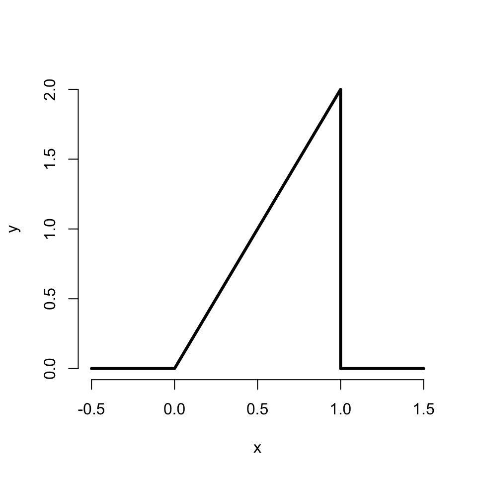

The total area of this triangle (probability of *anything* happening, is 1).

The probability that between 20% and 60% of the calls get addressed is represented by this region.

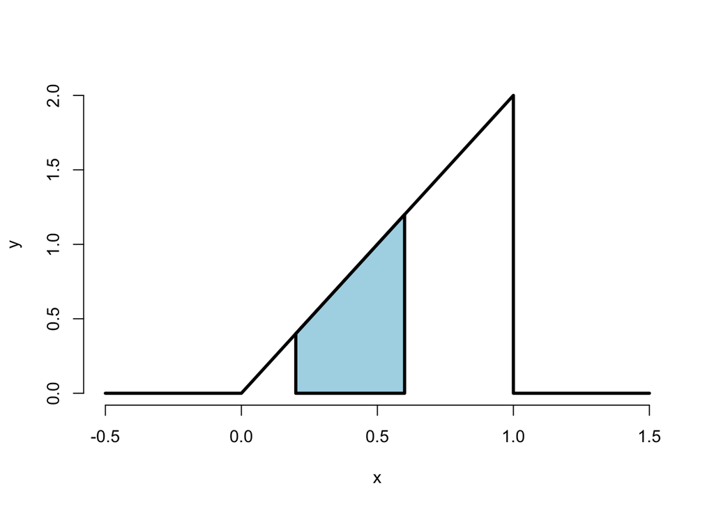

```r
plot(x, y, lwd = 3, frame = FALSE, type = "l")
polygon(c(0.2, .6, .6, 0.2), c(0, 0, 1.2, 0.4), lwd = 3, col = "lightblue")
```

What is the probability that 75% *or fewer* of the calls get addressed? That probability is represented by this region.

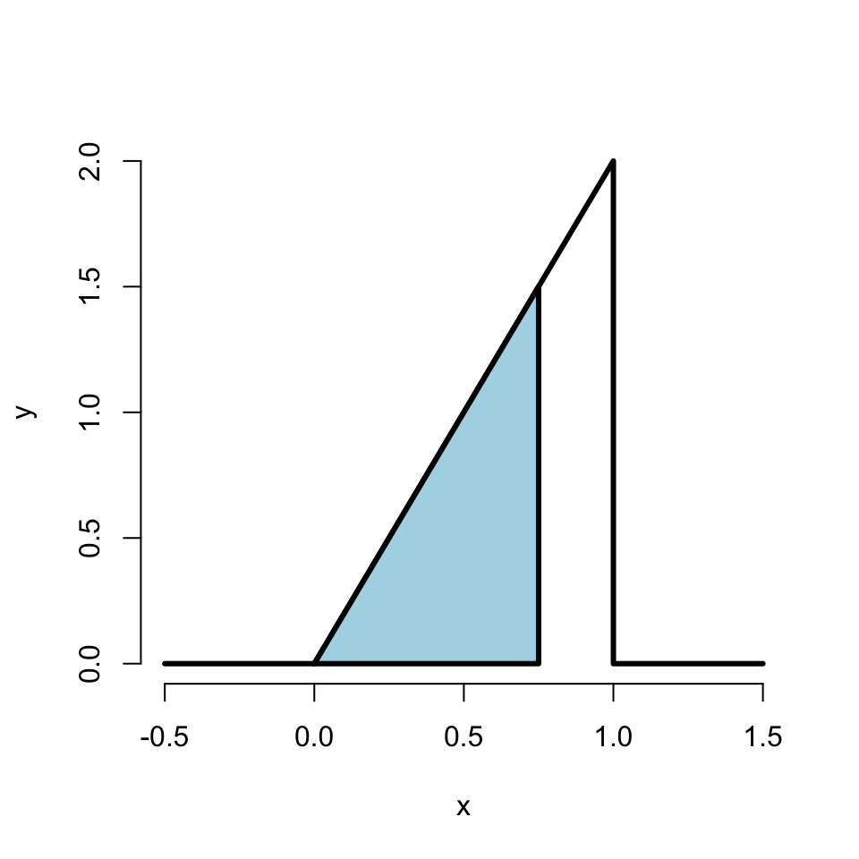

Doing the area calculation gives us the numeric probability.

$$A = {{b * h} \over 2}$$

```r
0.75 * 1.5 /2
```

```
## [1] 0.5625
```

This is a special case of a known density called the *beta distribution*.

Beta probability distribution function:
$$f(x; \alpha, \beta) = k \cdot x^{\alpha-1}(1-x)^{\beta -1}$$
The constant $k$ ensures that the probability integrates to 1. It is calculated from the **beta function.**

We can use R to get the probability directly from the cumulative distribution function of the beta distribution, via the *R probability function* for the *beta distribution*:

```r
# q = x,   shape1 = alpha,   shape2 = beta
pbeta(q=0.75, shape1=2, shape2=1)
```

```
## [1] 0.5625
```

### CDF and Survival Function

The cumulative distribution function $F(x)$ tells us the probability of a certain relationship between $X$ and $x$. Specifically, the cdf tells us the probability that the random variable $X$ has a value less than or equal to whatever $x$ is.

$$F(x) = P(X \leq x)$$

Which means “the probability that a specific known outcome is less than a random input”. In the case of our previous example:

> What is the probability that only 75% of the calls get addressed?

The pbeta function

```r
pbeta(q=0.75, shape1=2, shape2=1)
```

returns the probability of a random input generating an output (which is also a probability) less than 0.75, $(X)$.

The survival function $S(x)$ is sort of the opposite of the cdf.
$$S(x) = P(X > x)$$

Also, sf = 1 - cdf: $S(x) = 1 - F(x)$

If we want to know the probability that 60% *or more* of the calls get addressed, we could calculate $S(0.6)$. More commonly, we calculate $1 - F(x)$; in R:

```r
1 - pbeta(0.6, 2, 1);
```

```
## [1] 0.64
```

### Quantiles

A *sample quantile* is the nth percentile of a croup of measurements. To find the 80th percentile, for example, we order all the measurements, and the find the one such that 80% of the measurements are below it, and 20% are above.

In probability distributions, the $\alpha^{th}$ **quantile** of a distribution with function $F(x_\alpha)$ is the point $x_\alpha$ so that
$$F(x_\alpha) = \alpha$$

It’s the same principle as working with sample quantiles, just more complicated to calculate.

#### Example - Median of a distribution

What is the median (50th percentile) of our previous distribution of calls?

I need to calculate the random input $x$ for the CDF equaling one half $F(x) = 0.5$. Fortunatey the beta distribution is just triangles, and $X$ vanishes, making it easy:
$$F(x) = P(X \leq x) = {1 \over 2} Base \times Height = {1 \over 2}(x) \times (2x) = x^2$$

$$\therefore F(x) = x^2$$

We need to solve now
$$0.5 = F(x) = (x)^2 \therefore x = \sqrt{(0.5)} = 0.7071$$
**This means that**

1. On 50% of the days, less than 70% of the calls get answered
2. On 50% of the days, more than 70% of the calls get answered
3. 70% is the median ratio of calls that get answered
4. Half the time, more are answered
5. Half the time, fewer are answered

Again, we can do this with the *R quantile function* for the *beta distribution*

```r
qbeta(p = 0.5, shape1 = 2, shape2 = 1)
```

```
## [1] 0.7071068
```

## 0301 Conditional Probability

Also called *Bayesian*. Bayesian statistics *condition* a system based on the current state of that system.

### Example - Lightning:

There is a 1 in 7 million chance of dieing from a lightning strike. However, if you’re standing in an empty field during a thunderstorm, you must *condition* your probability due to the current system state – that you’re standing in a fucking thunderstorm. Your actual probability is much higher than 1 in 7 million.

### Example - A Die:

Each face on a die has a $1 \over 6$ probability of occuring. But, if you know that the result of a previous roll was an odd number, you would use that information to *condition* the outcome probabilities such that $P(1 \cup 3 \cup 5) = 1$ and $P(2 \cup 4 \cup 6) = 0$

### Definition

The probabilitiy of outcome A, **if** outcome B has **already** happened, is the quotient of the probabilities of both A and B happening, and only B happening. (The probability of the AB intersection divided by the probability of B)

$$P(A | B) = {{P(A \cap B)} \over {P(B)}}$$

If A and B are *statistically independent*, then the probability of A, **if** B has already happened, is
$$P(A | B) = {{P(A) \times P(B)} \over {P(B)}} = P(A)$$
The new information that B has occurred tells us nothing about the probability of A occurring.

#### Example - A Die Roll:

If a die roll is odd, then what is the probability that a 1 is rolled?

$$A = {1}$$
$$B = {1,3,5}$$

$$P(A | B) = {P(A \cap B) \over P(B)}$$
Since the set A lies *completely* within the set B $\left ( A \in B\right )$, the conditional probability formula reduces to
$$P(A | B) = {P(A) \over P(B)}$$

$$P(A | B) = { 1/6 \over 3/6} = {1 \over 3}$$

## 0302 Bayes’ Rule

Bayes’ rule allows us to reverse A and B. If we know the probability that A occurs, what is the probability that the broader event B occurs?

Or

If we know $P(A | B)$ then what is $P(B|A)$ ?

$$P(B | A) =
{
{P(A|B)P(B)}
\over
{P(A|B)P(B) + { P(A|B^c)P(B^c)}}
}$$
Which is $P(A|B)P(B)$, divided by itself plus a conditioning parameter.

### Diagnostic Tests

Apply conditional probability to medical diagnostic tests.

Define :

- $+$ = a positive test result
- $-$ = a negative test result
- $D$ = person really has the disease (outcome)
- $D^c$ = person doesn’t really have the disease (outcome)
- $tp$ = true positive
- $tn$ = true negative
- $fp$ = false positive
- $fn$ = false negative
- Sensitivity = probability of true positives
  - **If** a person has the disease, **then** what is the probability of a positive test result?
  - $Sensitivity = P(tp) = P(+ | D)$
- Specificity = probability of true negatives
  - **If** a person is healthy, **then** what is the probability of a negative test result?
  - $Specificity = P(tn) = P(- | D^c)$
- Positive predictive value = probability of disease, given a $+$ test result
  - the Bayesian reversal of the Sensitivity
  - $\mbox{Positive Predictive Value} = P(D | +)$
- Negative predictive value = probability of health, given a $-$ test result
  - the Bayesian reversal of the Specificity
  - $\mbox{Negative Predictive Value} = P(D^c | -)$
- Prevalence of disease = probability having the disease; independent to test results
  - $\mbox{Prevalence of Disease} = P(D)$

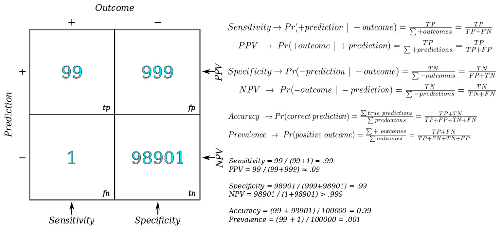

#### Example - HIV Tests:

> HIV tests have a sensitivity of 99.7% and a specificity of 98.5%. A population has a 0.1% prevalence of HIV, and a person from this group has a positive test. What is the associated positive predictive value>?

We have enough information to solve directly

$$P(B | A) = {
{P(A|B)P(B)}
\over
{P(A|B)P(B) + { P(A|B^c)P(B^c)}} }$$

**Note:** $P(+|D^c) = (1 - P(-|D^c))$

$$P(D | +) = {
{P(+|D)P(D)}
\over
{P(+|D)P(D) + { (1 - P(-|D^c))P(D^c)}} }$$

$$P(D | +) = {
{Sensitivity \times Prevalence}
\over
{Sensitivity \times Prevalence + {(1 - Specificity) \times (1-Prevalence)}} }$$

$$P(D | +) = {
{.997 \times .001}
\over
{.997 \times .001 + { (1 - .985) \times (1-.001)}} }$$

```r
(.997 * .001)/ (.997*.001 + (1-.985)*(1-.001))
```

```
## [1] 0.06238268
```

The positive predictive value of this test for this population is 6%. When a person from this group tests positive, there is only a 6% chance that they really have HIV.

> What if a person from this population is an IV drug user who has sex with HIV-positive partners?

This changes the *condition* of the system. The prevalence of disease $P(D)$ for this person is higher, which increases the PPD of this test for the individual.

### Likelihood Ratios

The positive predictive value is the probability of a **true positive**, and depends only on the sensitivity, specificity, and prevalence of disease.
$$P(D | +) = {
{P(+|D)P(D)}
\over
{P(+|D)P(D) + { (1 - P(-|D^c))P(D^c)}} }$$

The probability of a **false positive** also depends only on the sensitivity, specificity, and prevalence. It is equal to 1 minus the PPD.

$$P(D^c|+) = 1 - P(D | +) = {
{P(+|D^c)P(D^c)}
\over
{P(+|D)P(D) + { P(+|D^c)P(D^c)}} }$$

**Note:** $P(+|D^c) = (1 - P(-|D^c))$

$$P(D^c | +) = {
{(1 - Specificity) \times (1 - Prevalence)}
\over
{Sensitivity \times Prevalence + { (1 - Specificity) \times (1-Prevalence)}} }$$

The **likelihood ratio** is the true positive probability, divided by the false positive probability.
Dividing our long tp and fp equations simplifies to:
$${P(D|+) \over P(D^c|+)} = {P(+|D) \over P(+|D^c)} \times {P(D) \over P(D^c)}$$

In general, $P \over {1-P}$ gives us the *odds* of something occuring. In our example the far left term gives the odds of having HIV, if you get a positive test result. The far right term is the odds of having HIV in this population (unrelated to testing). The middle term is the **diagnostic likelihood ratio** for a positive test result.

Simply:
$$\mbox{Post-test odds of disease} = \mbox{Diagnostic likelihood ratio} \times \mbox{Pre-test odds of disease}$$

or

$$D_{post} = DLR_+ \times D_{pre}$$

or

$$tp = DLR_+ \times fn$$

or

$$Sensitivity = DLR_+ \times (1 - Specificity)$$

> Apply this to the HIV example

$$DLR_{HIV+} = {Sensitivity \over (1 - Specificity)} = {.997 \over (1 - .985) \approx 66}$$

Interpretation:

- If you have a positive test, post-test odds of disease are 66 times greater than pre-test odds
- Hypothesis of disease is 66 times more supported by the data than hypothesis of no-disease
- Small pre-test odds don’t really change when multiplied by 66
- Large pre-test odds increase quite a bit

What should we think about a negative HIV test?

$$\mbox{Post-test odds of disease} = \mbox{Diagnostic likelihood ratio} \times \mbox{Pre-test odds of disease}$$

or

$$D_{post}^{c} = DLR_- \times D_{pre}^{c}$$

or

$$fp = DLR_- \times tn$$

or

$$(1 - Sensitivity) = DLR_- \times Specificity$$

> Find the diagnostic likelihood ratio of a negative test

$$DLR_- = { (1 - Sensitivity) \over Specificity = { (1 - .997) \over .985 } \approx .003 }$$

Interpretation:

- If you have a negative test, post-test odds of disease are .003 times the pre-test odds
- Hypothesis of disease is .003 times more supported by the data than hypothesis of no-disease
- Both Large & Small pre-test odds change significantly when multiplied by .003

## 0303 Independence

## 0401 Expected Values

Rather than talking about the mass and density functions, we’ll restrict ourselves to talking about *characteristics* of these functions. Because of math, these characteristics also characterize the random variables $X$ that are drawn from these functions.

Sample quantiles are one of these characteristics. Another is the *Expected Value*.

The distribution mean is the most expected value. It’s a characterization of the distribution’s center. Variance is another expected value – the spread-outedness of a distribution.

Just as sample quantiles estimate population quantiles (0203), *sample* expected values estimate *population* expected values. Ex: the sample mean will be an estimate of the population mean.

The expected value of the random variable $X$ is the sum of all possible values it can take, multiplied by the probability of each value.

$$E[X] = \sum_x xp(x)$$

The expectation value is like the center of mass of a distribution of outcomes. In this analogy, each mass is the probability of an outcome (often plotted as height), and the outcome itself is the displacement from the mean.

If all outcomes are equally likely, then the ‘center of mass’ of the data is the *empirical mean*
$$\bar X = \sum_{i=1}^n x_i p(x_i)$$
where $p(x_i) = 1/n$

### Example - Find the center of mass of the bars

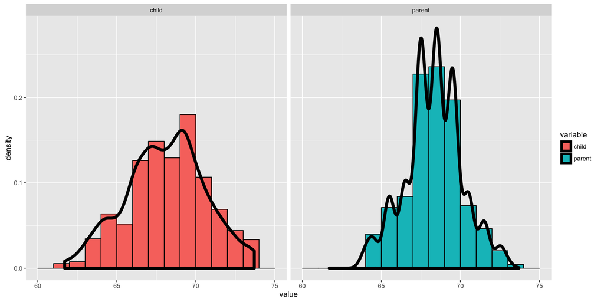

#### Using manipulate

```r
library(manipulate)
myHist <- function(mu){
    g <- ggplot(galton, aes(x = child))
    g <- g + geom_histogram(fill = "salmon",
      binwidth=1, aes(y = ..density..), colour = "black")
    g <- g + geom_density(size = 2)
    g <- g + geom_vline(xintercept = mu, size = 2)
    mse <- round(mean((galton$child - mu)^2), 3)
    g <- g + labs(title = paste('mu = ', mu, ' MSE = ', mse))
    g
}
manipulate(myHist(mu), mu = slider(62, 74, step = 0.5))
```

#### The center of mass is the empirical mean

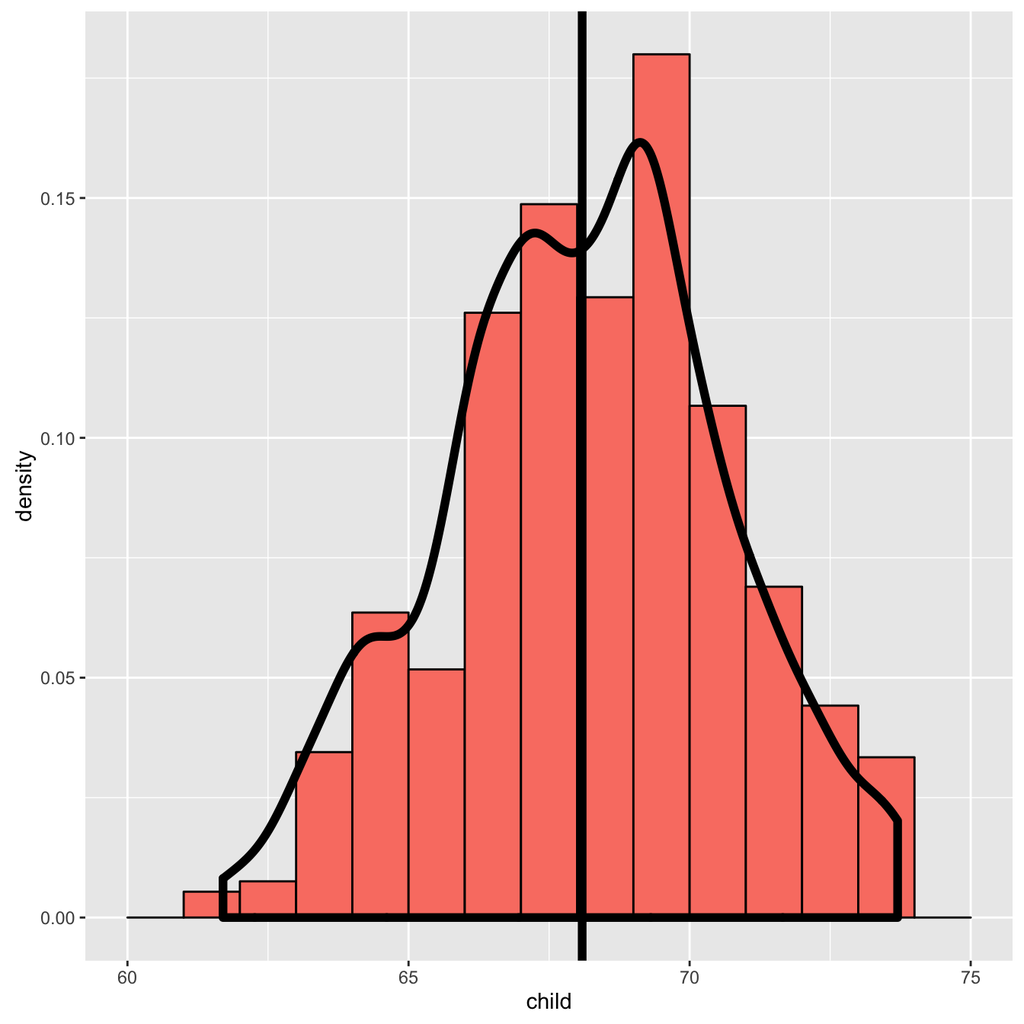

## 0402 Expected Value Examples

### Example of a population mean

A coin is flipped. $X$ = 0,1, corresponding to Heads, Tails.

What is the expected value of $X$?

$E \left [ X \right ] = .5 \times 0 + .5 \times 1 = .5$

The discrete outcome $\{0,1\}$ can never equal the expected value $0.5$

### What about a biased coin?

An unfair coin will show $\{H,T\}$ at some probability $\{p, 1-p \}$

$P(X=1) = p$ and $P(X=0) = (1-p)$

$$E[X] = \sum_x xP(x) = 1 * P(1) + 0 * P(0)$$
$$\quad = 1 * p + 0 * (1-p) = p$$

### A Die

A die is rolled. $X$ is the resulting number $1:6$.

What is the expected value of $X$ ?

All outcomes are equally likely (p is the same for all)
$$E[X] = \sum_{i=1}^n x_i p(x_i) = p(x_i) sum_{i=1}^n x_i$$
$$\quad = {1 \over 6 * (1+2+3+4+5+6)} = {21 \over 6} = 3.5$$

Again, the outcome ${1:6}$ can never equal $3.5$, but if you line up 6 bars, $3.5$ is in the geometric center of the alignment.

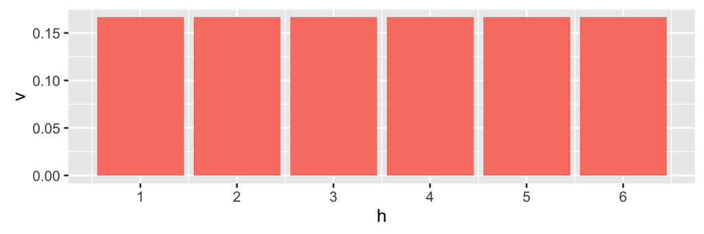

```r
library("ggplot2");

h <- 1:6; v <- rep(.167,6);
ggplot() + aes(h,v) + geom_bar(stat="identity", fill="salmon") + scale_x_continuous(breaks=seq(1,6,1));
```

## 0403 Expected Values for Probability Density Functions

The expected value is still the *center* of the density function. Think about the middle of the normal distribution, or any gaussian curve.

### Example - The uniform density

The expected value of the uniform density is $0.5$

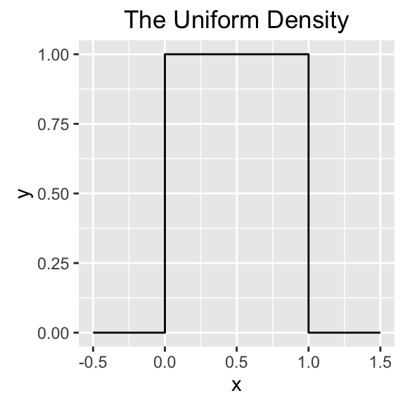

**Facts about expected values**

1. Expected values are *properties* of distributions
2. The average of all the random variable values is also a random variable
   - The average’s associated distribution has an expected value
3. **The average’s expected value is the SAME as the population’s expected value**
4. … The centers of the population and sample mean distributions are the same
   - When this happens, the *estimator* (sample mean) is unbiased

### Example - The Normal Distribution

The blue region is the normal distribution, sampled 10,000 times. The pink region is the distribution of averages of 10 of the normal samples.

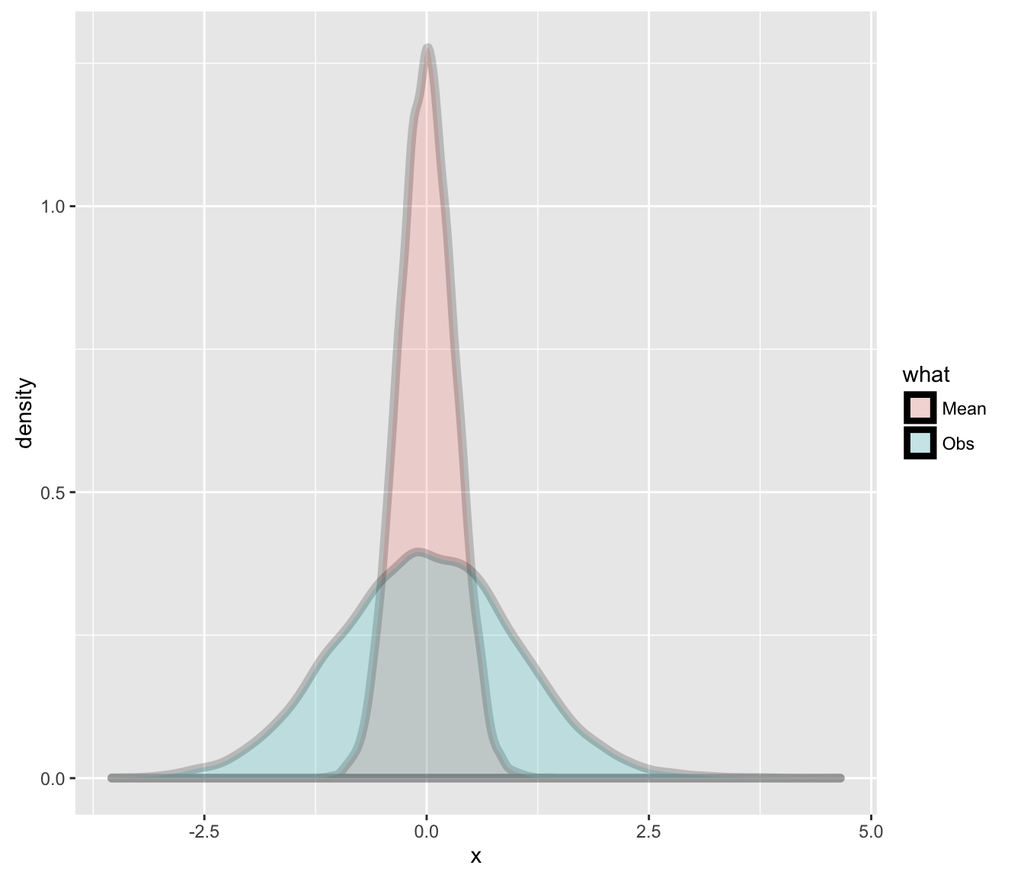

The two distributions are both centered at zero.

### Example - 10,000 Die rolls

1. Facet 1: 1 die roll - sampled 10,000 times
2. Facet 2: Average of 2 die rolls (population mean of)
3. Facet 3: Average of 3 die rolls (population mean of)
4. Facet 4: Average of 4 die rolls (population mean of)

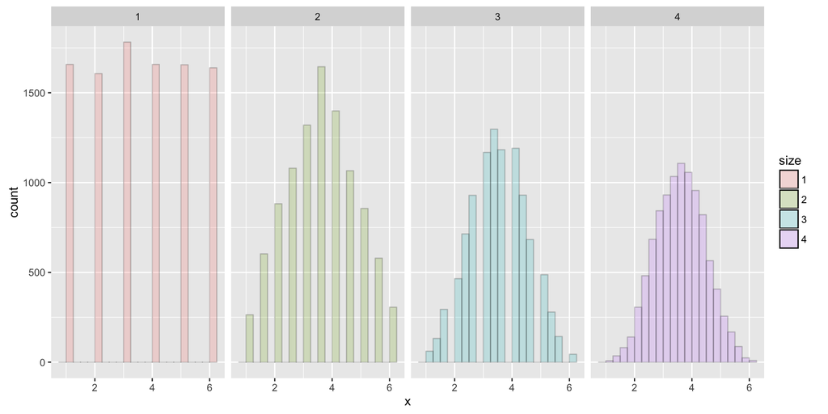

### Example - 10,000 Coin Flips

Facet 1: Results of coin flips ${0,1}$ Facet 2: Average value of 10 coin flips Facet 3: Average value of 20 coin flips Facet 4: Average value of 30 coin flips

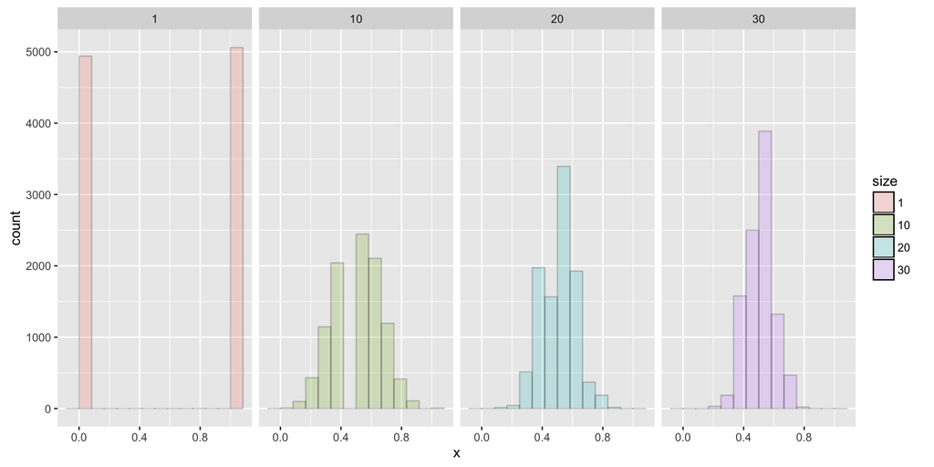

## Summary of Expected Values

1. Expected values are *properties* of distributions
2. The population mean is the center (of mass) of the *population distribution*
3. The sample mean is the center (of mass) of the *observed data*
4. The sample mean is always an estimate of the population mean
5. The sample mean is unbiased
   - The population mean of the sample mean distribution is the mean that the sample mean is trying to estimate
6. The more observations in the sample mean, the more it’s mass/density function concentrates around the population mean
   - ~ the sample mean density function is the Fourier transform of the population distribution ??